# Übungsblatt #2

Seyed Ramtin Hosseini

2024-11-24

## Übungsblatt 02

### Seyed Ramtin Hosseini

Studiengang: Informatik

#### Aufgabe 1

Für die erste Aufgabe habe ich ein Rmarkdown Dokument in Rstudio (mit HTML als output format) erstellt und die benötigte Metadaten eingegeben.

#### Aufgabe 2

a ) Der Datensatz wurde heruntergeladen und wurde in den Ordner “data” hinzugefügt

Installation und Verwendung des Pakets “tidyverse”

```r
install.packages('tidyverse')
```

```r
library(tidyverse)
```

Den Datensatz laden

```r
oktoberfestDatensatz <- read_csv("data/oktoberfestgesamt19852023.csv")
```

Verwendung der Funktion head(), um die erste 10 Zeilen des Datensatez auszugeben

```r
head(oktoberfestDatensatz, n=10)
```

```
## # A tibble: 10 × 8
##     jahr dauer besucher_gesamt besucher_tag bier_preis bier_konsum hendl_preis
##    <dbl> <dbl>           <dbl>        <dbl>      <dbl>       <dbl>       <dbl>
##  1  1985    16             7.1          444       3.2        54541        4.77
##  2  1986    16             6.7          419       3.3        53807        3.92
##  3  1987    16             6.5          406       3.37       51842        3.98
##  4  1988    16             5.7          356       3.45       50951        4.19
##  5  1989    16             6.2          388       3.6        51241        4.22
##  6  1990    16             6.7          419       3.77       54300        4.47
##  7  1991    16             6.4          400       4.21       54686        4.81
##  8  1992    16             5.9          369       4.42       48888        5.11
##  9  1993    16             6.5          406       4.71       51933        5.25
## 10  1994    16             6.6          413       4.89       52108        5.39
## # ℹ 1 more variable: hendl_konsum <dbl>
```

1. *jahr*: numerisch (min: 1985, max: 2023)
2. *besucher_gesamt*: numerisch (min: 5.5, max: 7.2)
3. *bier_preis: numerisch:* (min: 3.2, max: 14.33)
4. *bier_konsum*: numerisch (min: 48698 , max: 79225)

##### Code für diese Aufgabe:

```r
#Year
yearColumn <- oktoberfestDatensatz$jahr

typeOfYearColumn <- typeof(yearColumn)
classOfYearColumn <- class(yearColumn)
if (is.numeric(yearColumn)) {
  #Minimum Value
  min_value <- min(yearColumn, na.rm = TRUE)  # Use na.rm = TRUE to ignore missing values (NA)
  # Maximum value
  max_value <- max(yearColumn, na.rm = TRUE)

  cat("Jahr:",typeOfYearColumn,"(min:",min_value,", max:", max_value, ")")
} else {
  cat("Jahr:",typeOfYearColumn,"(min:",min_value,", max:", max_value, ")")
}
```

```
## Jahr: double (min: 1985 , max: 2023 )
```

```r
#Total Visitor
visitorTotalColumn <- oktoberfestDatensatz$besucher_gesamt

typeOfVisitorTotalColumn <- typeof(visitorTotalColumn)
classOfVisitorTotalColumn <- class(visitorTotalColumn)
if (is.numeric(visitorTotalColumn)) {
  #Minimum Value
  min_value <- min(visitorTotalColumn, na.rm = TRUE)  # Use na.rm = TRUE to ignore missing values (NA)
  # Maximum value
  max_value <- max(visitorTotalColumn, na.rm = TRUE)

  cat("Gesamt Besucher:",typeOfVisitorTotalColumn,"(min:",min_value,", max:", max_value, ")")
} else {
  cat("Gesamtbesucher:",typeOfVisitorTotalColumn,"(min:",min_value,", max:", max_value, ")")
}
```

```
## Gesamt Besucher: double (min: 5.5 , max: 7.2 )
```

```r
#Price of Beer
priceBeerColumn <- oktoberfestDatensatz$bier_preis

typeOfPriceBeerColumn <- typeof(priceBeerColumn)
classOfPriceBeerColumn <- class(priceBeerColumn)
if (is.numeric(priceBeerColumn)) {
  #Minimum Value
  min_value <- min(priceBeerColumn, na.rm = TRUE)  # Use na.rm = TRUE to ignore missing values (NA)
  # Maximum value
  max_value <- max(priceBeerColumn, na.rm = TRUE)

  cat("Bierpreis:",typeOfYearColumn,"(min:",min_value,", max:", max_value, ")")
} else {
  cat("Bierpreis:",typeOfYearColumn,"(min:",min_value,", max:", max_value, ")")
}
```

```
## Bierpreis: double (min: 3.2 , max: 14.33 )
```

```r
#Beer Consume
bierConsumeColumn <- oktoberfestDatensatz$bier_konsum

typeOfBierConsumeColumn <- typeof(bierConsumeColumn)
classOfBierConsumeColumn <- class(bierConsumeColumn)
if (is.numeric(bierConsumeColumn)) {
  #Minimum Value
  min_value <- min(bierConsumeColumn, na.rm = TRUE)  # Use na.rm = TRUE to ignore missing values (NA)
  # Maximum value
  max_value <- max(bierConsumeColumn, na.rm = TRUE)

  cat("Bierkonsum:",typeOfBierConsumeColumn,"(min:",min_value,", max:", max_value, ")")
} else {
  cat("Bierkonsum:",typeOfBierConsumeColumn,"(min:",min_value,", max:", max_value, ")")
}
```

```
## Bierkonsum: double (min: 48698 , max: 79225 )
```

### Aufgabe 3

a )

ggpolt hinzufügen

```r
library(ggplot2)
```

Erstellung Bar-Plot mit ggplot in dem die unterschiedlichen Dauern des Oktoberfests über die Jahre hinweg.

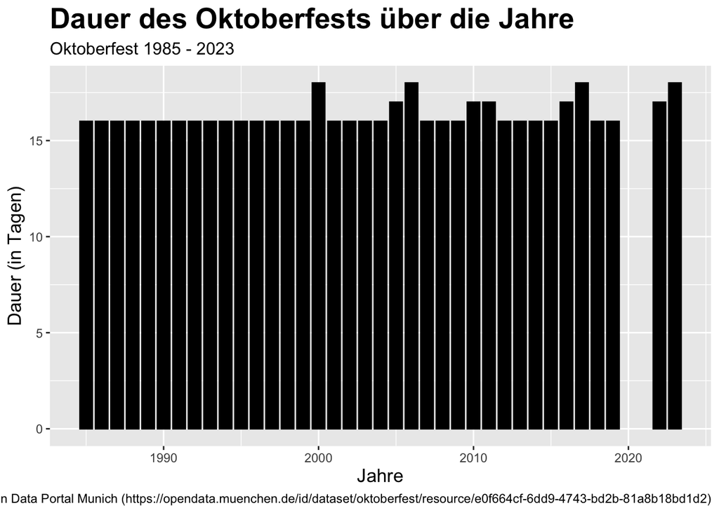

```r
#Dauer über die Jahre
ggplot(oktoberfestDatensatz) +
  aes(x = jahr, y = dauer) +
  geom_bar(stat = "identity", fill = "black", colour = "black", width = 0.8) +
  labs(
    x = "Jahre",
    y = "Dauer (in Tagen)",
    title = "Dauer des Oktoberfests über die Jahre",
    subtitle = "Oktoberfest 1985 - 2023",
    caption = "Open Data Portal Munich (https://opendata.muenchen.de/id/dataset/oktoberfest/resource/e0f664cf-6dd9-4743-bd2b-81a8b18bd1d2)"
  ) +
  theme_gray() +
  theme(
    plot.title = element_text(size = 20L, face = "bold"),
    plot.subtitle = element_text(size = 12L),
    axis.title.y = element_text(size = 13L),
    axis.title.x = element_text(size = 13L)
  )
```

**Beschreibung**: Die Grafik zeigt die Dauer des Oktoberfests (in Tagen) in verschiedenen Jahren von 1985 bis 2023. Zum Darstellung der Daten wurde hier einen Bar-Plot genutzt.

#### Was ist die häufigste Dauer des Oktoberfests?

**Antwort: 16 ,** Anhand der Grafik, kann man dies erkennen.

Erstellung einen Scatter-Plot mit dem Jahr auf der x-Achse und der Anzahl Besucher (in Millionen) auf der y-Achse.

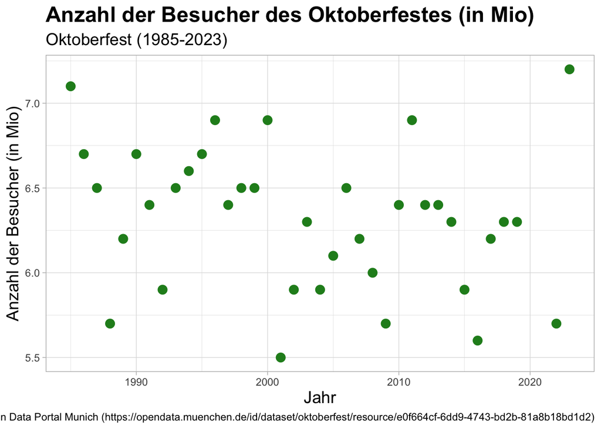

```r
#Besucher über die Jahre
ggplot(oktoberfestDatensatz) +
  aes(x = jahr, y = besucher_gesamt) +
  geom_point(size = 5L, shape = "bullet", colour = "#228B22") +
  labs(x = "Jahr", y = "Anzahl der Besucher (in Mio)", title = "Anzahl der Besucher des Oktoberfestes (in Mio)", subtitle = "Oktoberfest (1985-2023)",
       caption = "Open Data Portal Munich (https://opendata.muenchen.de/id/dataset/oktoberfest/resource/e0f664cf-6dd9-4743-bd2b-81a8b18bd1d2)") +
  theme_light() +
  theme(legend.justification = "top", plot.title = element_text(size = 18L, face = "bold"),
        plot.subtitle = element_text(size = 14L), axis.title.y = element_text(size = 14L), axis.title.x = element_text(size = 14L),
        legend.text = element_text(size = 12L), legend.title = element_text(size = 12L))
```

**Beschreibung**: Die Grafik zeigt die Anzahl der Besucher des Oktoberfests (in Millionen) in verschiedenen Jahren von 1985 bis 2023. Zum Darstellung der Daten wurde hier einen Scatter-Plot genutzt.

#### Aufgabe 4

Erstellung einen Line-Plot in dem der Bier-Preis auf dem Oktoberfest über die Jahre hinweg angezeigt wird.

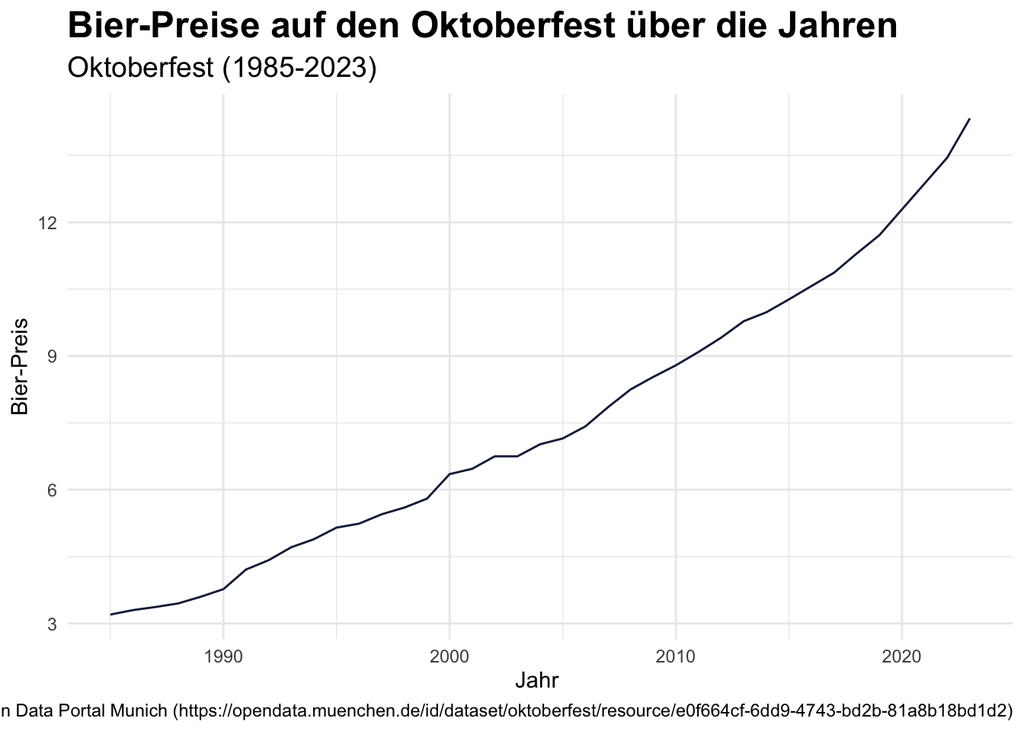

```r
#Bier-Preise über die Jahren
ggplot(oktoberfestDatensatz) +
  aes(x = jahr, y = bier_preis) +
  geom_line(colour = "#112446") +
  labs(x = "Jahr ", y = "Bier-Preis",
       title = "Bier-Preise auf den Oktoberfest über die Jahren", subtitle = "Oktoberfest (1985-2023)",
       caption = "Open Data Portal Munich (https://opendata.muenchen.de/id/dataset/oktoberfest/resource/e0f664cf-6dd9-4743-bd2b-81a8b18bd1d2)") +
  theme_minimal() +
  theme(plot.title = element_text(size = 18L, face = "bold"), plot.subtitle = element_text(size = 14L))
```

Erstellung einen Line-Plot in dem der Bier-Konsum auf dem Oktoberfest über die Jahre hinweg angezeigt wird.

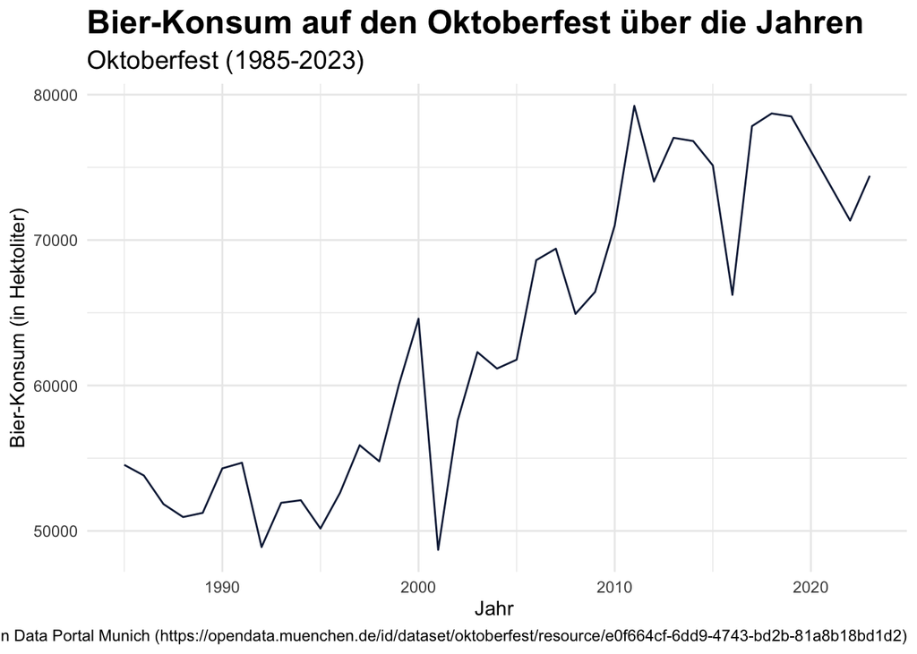

```r
#Bier-Konsum über die Jahren
ggplot(oktoberfestDatensatz) +
  aes(x = jahr, y = bier_konsum) +
  geom_line(colour = "#112446") +
  labs(x = "Jahr ", y = "Bier-Konsum (in Hektoliter)",
       title = "Bier-Konsum auf den Oktoberfest über die Jahren", subtitle = "Oktoberfest (1985-2023)",
       caption = "Open Data Portal Munich (https://opendata.muenchen.de/id/dataset/oktoberfest/resource/e0f664cf-6dd9-4743-bd2b-81a8b18bd1d2)") +
  theme_minimal() +
  theme(plot.title = element_text(size = 18L, face = "bold"), plot.subtitle = element_text(size = 14L))
```

Rekonstrution den gegebenen Plot

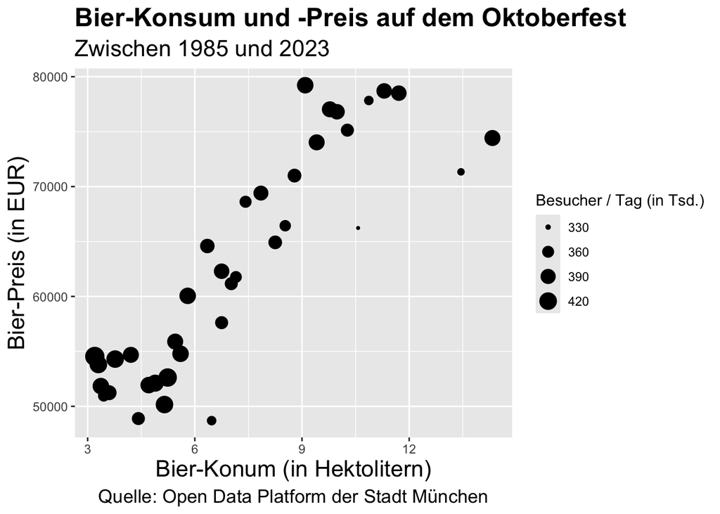

```r
#Bier-Konsum und -Preis auf dem Oktoberfest.
ggplot(oktoberfestDatensatz) +
  aes(x = bier_preis, y = bier_konsum, size = besucher_tag) +
  geom_point(shape = "circle small",
             colour = "#000000") +
  labs(x = "Bier-Konum (in Hektolitern)", y = "Bier-Preis (in EUR)", size = "Besucher / Tag (in Tsd.)" ,title = "Bier-Konsum und -Preis auf dem Oktoberfest",
       subtitle = "Zwischen 1985 und 2023", caption = "Quelle: Open Data Platform der Stadt München") +
  theme_gray() +
  theme(plot.title = element_text(size = 18L, face = "bold"), plot.subtitle = element_text(size = 16L),
        plot.caption = element_text(size = 13L, hjust = 0.5), axis.title.y = element_text(size = 16L), axis.title.x = element_text(size = 16L))
```

**Beschreibung**:

Der Scatter-Plot beschreibt den Bierpreis (von 1 Euro bis 15 Euro) sowie den Bierkonsum auf dem Oktoberfest von 1985 bis 2023. Die Größe der Kreisen bescheibt die Anzahl der Besucher im Tag (in 1000). Man kann sehen, dass die Bier-Preise und Bier-Konsum eine relativ lineare Beziehung haben.

**Glaubt ihr der Bier-Preis und die Menge die an Bier getrunken wird hängen miteinander zusammen? Warum / Warum nicht?**

**Ja**, Wir können im Plot eine klare Linie erkennen. Dies deutet darauf hin, das der Bier-Preis und -Konsum zusammenhängt.

**Nein**, es ist klar dass wir eine lineare Beziehung zwischen den Bier-Preis und Bier Konsum sehen können. Jedoch es deutet nicht hauptsächlich darauf, dass die beide zusammenhängen. Ein Argument ist, dass beide in den letzten Jahren zugenommen haben, also sind beide vielleicht nicht miteinander verbunden und beide sind nur aufgrund eines anderen Arguments gestiegen, hauptsächlich aufgrund der Zeit.

“Insgesamt wurden von 1985 - 2023 20,727,002 Hendl gegessen.”

Code:

```r
hendl_gesamt <- sum(oktoberfestDatensatz$hendl_konsum)
print(paste("Insgesamt wurden von 1985 - 2023 ", format(hendl_gesamt, big.mark = ","), "Hendl gegessen."))
```

```
## [1] "Insgesamt wurden von 1985 - 2023  20,727,002 Hendl gegessen."
```

#### Aufgabe 5

```r
aktivBeschaeftigte <- read_csv("data/lhm-personal-aktiv-beschaeftigte.csv")
head(aktivBeschaeftigte)
```

```
## # A tibble: 6 × 5
##    jahr insgesamt `davon-gemeindehaushalt` `davon-eigenbetriebe`
##   <dbl>     <dbl>                    <dbl>                 <dbl>
## 1  2023     41078                    36347                  4580
## 2  2022     40532                    35856                  4529
## 3  2021     40589                    35896                  4545
## 4  2020     40971                    36396                  4420
## 5  2019     40188                    35839                  4200
## 6  2018     39450                    35386                  3934
## # ℹ 1 more variable: `davon-rechtllich-selbststaendige-stiftungen` <dbl>
```

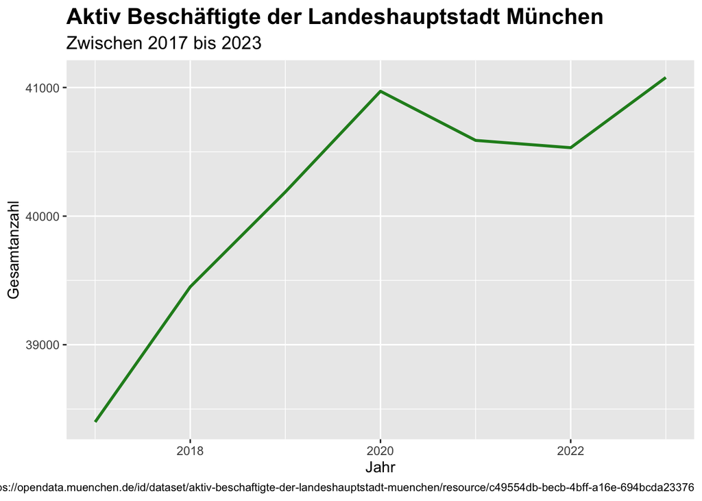

```r
ggplot(aktivBeschaeftigte) +
 aes(x = jahr, y = insgesamt) +
 geom_line(linewidth = 1L, colour = "#228B22") +
 labs(x = "Jahr", y = "Gesamtanzahl", title = "Aktiv Beschäftigte der Landeshauptstadt München",
subtitle = "Zwischen 2017 bis 2023", caption = "Quelle https://opendata.muenchen.de/id/dataset/aktiv-beschaftigte-der-landeshauptstadt-muenchen/resource/c49554db-becb-4bff-a16e-694bcda23376") +
 theme(plot.title = element_text(size = 16L, face = "bold"), plot.subtitle = element_text(size = 13L),
 plot.caption = element_text(size = 8L))
```

Beschreibung:

Der Grafik zeigt die Anzahl der Akitvbeschäftigte (**Aktiv Beschäftigte** = Beschäftigte (Beamte*innen und Tarifbeschäftigte) mit regelmäßigen Zahlungen.) der Landeshauptstadt München in verschieden Jahren zwischen 2017 und 2023.

Auf der X-Achse sieht man die Jahren und auf der Y-Achse die Gesamtanzahl. Ich hab Line-Plot genutzt, damit man besser die Änderung der Gesamtanzahl der Aktivbescgäftigte der Landeshauptstadt München in verschieden Jahren sehen kann.